# Is BorrowerAPR deteremined by any factors?

## by Sheila I. John

## Investigation Overview

This presentation will show the distribution of the original loan amount and how people borrow for their different categories(reasons). It will also show if any factors affect the borrower interest rate and what these factors are.

## Dataset Overview

This analysis is based on a data from Kaggle made available by Udacity. Prosper is an online peer-to-peer lending platform which matches borrowers (looking for personal loans between \$2,000 and \\$40,000) with investors. The data set contains 113,937 loan listings with 81 variables. The variables are a mix of alpha and numeric. Most of the data is shared into pre-2009 and post-2009.

## Distribution of LoanOriginalAmount

The Original amount loaned peaks around \$4,500. We can see highs at about \\$11,000 and \$15,000. There is no smooth progression but there is quite a concentration on figures between \\$5,000 and \$15,000

```
Text(0.5,1,'Distribution of Original Loan Amount')
```

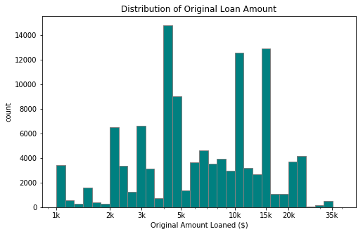

## Employment Status and Income range

Here's we see how many of the borrowers are employed and fot those who are employed we see which income group borrows the most.

```
Text(0.5,1,'No of Listings per Income Range')
```

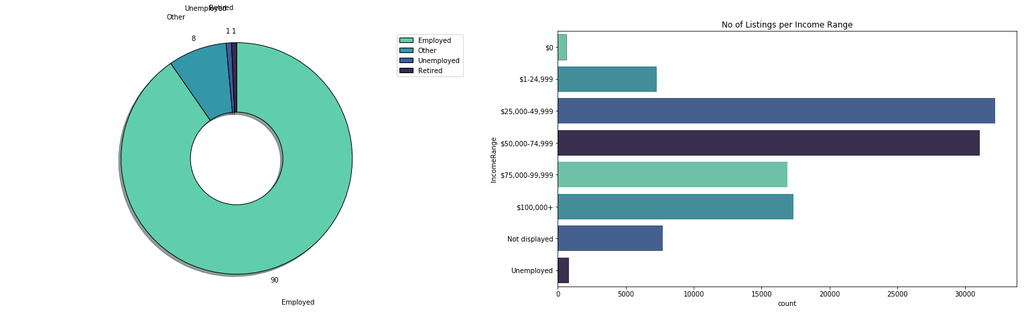

## Listing Category

Here the listing categories have been put in words and we see for what reasons people borrow the most.

```
Text(0.5,1,'Reasons people take Loans')
```

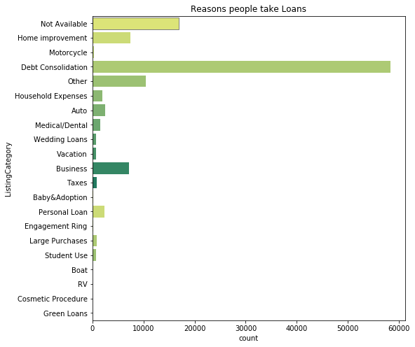

## BorrowerAPR vs IncomeRange

The central line shows the median value. From the chart it is clear that people who earn the most, have the lowest median borrower annual percentage rate

```
Text(0.5,1,'Borrower APR by IncomeRange')
```

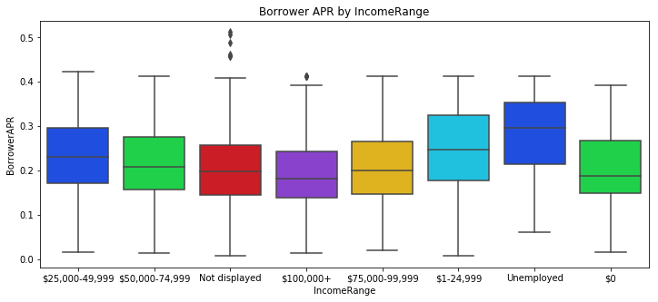

## BorrowerAPR vs ProsperScore

There are quite some outliers here but the focus is on the median value. The results show that the less risk a borrower poses (that is the higher their prosper score), the less their interest rate. Perhaps this could be influenced by the investors confidence in the loan being repayed without default.

```
Text(0.5,1,'BorrowerAPR by Prosper score')
```

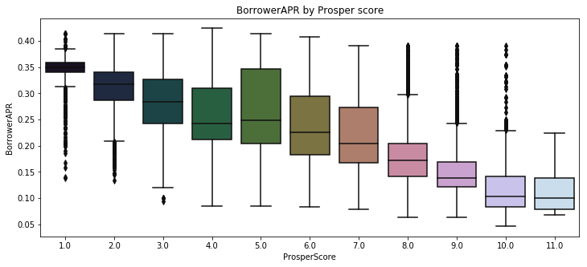